# The Most At-Risk Populations for Chronic Absenteeism in NYC Public Schools

Author

Anaan Choudhury, Karen Galvan and Naylynn Tañón Reyes

# Abstract

In New York City, chronic absenteeism is defined as missing 18 or more days of school. With students at risk for academic underperformance, especially due to the tumultuous learning environment due to the pandemic, creating equitable education for students is vital. But which populations are most at risk? To answer this question, we compared factors of students’ identities to search for a correlation between certain populations and chronic absenteeism. Our study shows there is a significant correlation between the number of students living in poverty and the number of students who are chronically absent. Additionally, there is a positive correlation between students who are English language learners, living in poverty, and living with disabilities and chronic absenteeism in schools which we explored through an additive model.

# Introduction

By using the NYC public school system as a sample for the United States public school system, we will answer the question “What variables drive chronic absenteeism in NYC public schools?”. We will be investigating whether certain independent variables impact higher rates of chronic absenteeism. Our data sets include demographic information like ethnicity, gender, non-native English speakers, poverty levels, and disability status at the individual school level.

We hypothesize that there is a positive correlation between poverty level, disability status, non-native English speaking students and chronic absenteeism rates for students in the NYC public school system. In general, we also suppose that all marginalized students have higher rates of absenteeism in the NYC public school system due to the lack of planning for equity.

# Methods

We used the data sets provided by NYC Open Data, which is free public data published by New York City agencies and other partners. Specifically, we used the “2016-17 - 2020-21 School End-of-Year Attendance and Chronic Absenteeism Data” and the “NYC Open Data - 2017-18 - 2021-22 Demographic Snapshot”, which we joined by “DBN”, or the district borough number, which uniquely identifies a school in the five borough districts. The former tells us about the total number of chronically absent students for a given school or “DBN”, along with the total number of absences for the year, and the total number and percentage of chronically absent students. The Demographic Snapshot data, on the other hand, provides information on students at the school-wide level, along with representative information pertaining to grade level, sex, ethnicity/race, disability status, English language learners, and poverty level. All investigations were conducted through the Board of Education on the school level, rather than on individual students.

After joining both data frames we had to select our variables. The variables used in our analysis include percentages of chronically absent students, poverty level, disability status, and students who are English language learners. All of these are expressed as percentages of students out of the total student bodies at individual New York City public schools (including grades Kindergarten through 12th grade). We specifically chose these variables because of the repeated institutional discrimination against these marginalized groups in the United States throughout history.

Next, we removed all rows with N/As from the new data frame to clean the data. Then we had to do some formatting changes which included removing percentage signs from the column values. The Poverty and Chronically Absent columns then had their variable type converted from “char” to “num” in order to do calculations and were converted to the same written percentage format for consistency.

To begin our data exploration, we created a scatterplot with a regression line of the percentage of chronically absent students against the percentage of students below the poverty line to search for a relationship between the two variables.

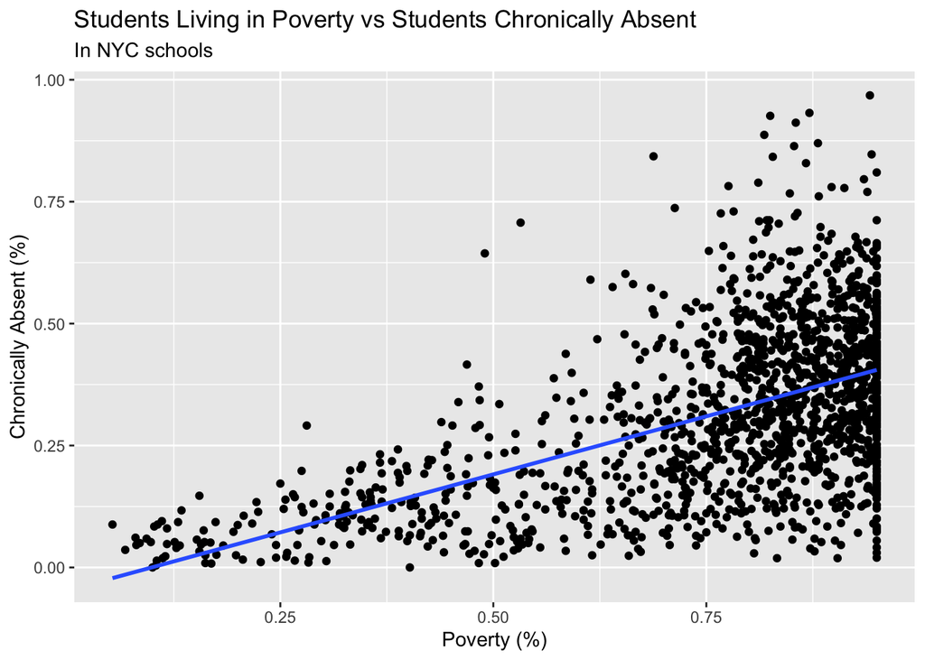

Next, we reported the regression table to interpret the coefficients and p-value of the regression line. Since we saw a p-value smaller than 0.05 and a positive linear correlation between our initial variables, Poverty and Chronically.Absent we decided to continue with this work and add more variables.

```
               Estimate Std. Error   t value      Pr(>|t|)
(Intercept) -0.04712545 0.01524435 -3.091338  2.028650e-03
Poverty      0.47596855 0.01920697 24.781030 3.331654e-114
```

Because we want to explore the relationships between a school’s reported chronic absenteeism and Poverty, English.Language.Learners and Students.with.Disabilities, a new regression table was created with the additional explanatory variables to check the p-values and remove those with a p-value greater than 0.05.

```
                              Estimate Std. Error   t value     Pr(>|t|)
(Intercept)                -0.08050046 0.01477039 -5.450126 5.862673e-08
Poverty                     0.45367609 0.02039543 22.244006 3.774391e-95
English.Language.Learners  -0.10069501 0.02744412 -3.669092 2.518001e-04
Students.with.Disabilities  0.27022199 0.02327341 11.610762 6.346969e-30
```

Since all of the variables have p-values less than 0.05, we can keep all of them for now.

Then a check for multicollinearity was performed to investigate whether certain variables were more strongly correlated with some combination of the other explanatory variables in the model. Multicollinearity causes uncertainty about each coefficients value from sample to sample to increase which then reduces the power of inference procedures, such as t-tests, to detect true relationships.

This was tested by calculating the variance inflation factor (VIF) Generally, VIF values > 10 are a sign of danger, while VIF values > 5 are a sign of caution. Here we see that the VIF values for all variables are below 5 therefore we are not concerned about this degree of multicollinearity

```
                   Poverty  English.Language.Learners
                  1.243215                   1.178901
Students.with.Disabilities
                  1.065248
```

Several models were created afterward by removing variables (reducing the complexity) in order to later compare the models. Then, by using the anova() function in R, we were used nested F-tests to compare the goodness of fit between each additive model.

```
Analysis of Variance Table

Model 1: Chronically.Absent ~ Poverty + English.Language.Learners
Model 2: Chronically.Absent ~ Poverty + English.Language.Learners + Students.with.Disabilities
  Res.Df    RSS Df Sum of Sq      F    Pr(>F)
1   1524 33.488
2   1523 30.765  1    2.7232 134.81 < 2.2e-16 ***
---
Signif. codes:  0 '***' 0.001 '**' 0.01 '*' 0.05 '.' 0.1 ' ' 1
```

The results indicate we should prefer absent_model_3var as the best balance of goodness of fit and model complexity. We then compared that model to the new models with interactions added usinig an nested F-test once again.

```
Analysis of Variance Table

Model 1: Chronically.Absent ~ Poverty + English.Language.Learners + Students.with.Disabilities
Model 2: Chronically.Absent ~ Poverty + English.Language.Learners * Students.with.Disabilities
  Res.Df    RSS Df Sum of Sq      F   Pr(>F)
1   1523 30.765
2   1522 30.387  1   0.37733 18.899 1.47e-05 ***
---
Signif. codes:  0 '***' 0.001 '**' 0.01 '*' 0.05 '.' 0.1 ' ' 1
```

```
Analysis of Variance Table

Model 1: Chronically.Absent ~ Poverty + English.Language.Learners + Students.with.Disabilities
Model 2: Chronically.Absent ~ Poverty * English.Language.Learners + Students.with.Disabilities
  Res.Df    RSS Df Sum of Sq      F Pr(>F)
1   1523 30.765
2   1522 30.724  1  0.041009 2.0315 0.1543
```

```
Analysis of Variance Table

Model 1: Chronically.Absent ~ Poverty + English.Language.Learners + Students.with.Disabilities
Model 2: Chronically.Absent ~ Poverty * English.Language.Learners * Students.with.Disabilities
  Res.Df    RSS Df Sum of Sq     F    Pr(>F)
1   1523 30.765
2   1519 30.325  4   0.44007 5.511 0.0002098 ***
---
Signif. codes:  0 '***' 0.001 '**' 0.01 '*' 0.05 '.' 0.1 ' ' 1
```

Here absent_model_interact3 and absent_model_interact1 show evidence that there is an interaction due to the p-values being less than 0.05 but the difference in RSS values is extremely small. This means that even though there is a statistically significant change when applying interaction to the model, due to the low RSS value, there is no practical change to the estimated rate of absenteeism. This leads us to believe that the interactions are not a necessary component of the model and that absent_model_3var, which is the reduced model, is still the best balance of goodness of fit and model complexity.

When we use linear regression models, we make assumptions about the relationship between the outcome and explanatory variables. Therefore we need to check if our model meets these assumptions. As you can see below, our model did not pass the tests for normality and equal variance.

In order to stabilize the variance we applied log to the outcome variable. However, because several schools had zero percent absenteeism and zero cannot be converted to the logarithmic scale we could not apply log transformation. Rather than omit valid observations and potentially bias our coefficients we chose to fit and interpret the model on the original scale regardless of the normality and equal variance violations. Therefore there is that to consider when reviewing our results. Still, note that T tests on the coefficients of regression models are generally robust to the violations of normality and equal variance. Therefore, it would take an incredibly large violation of normality to get the sampling distribution and give it a different shape so a violation like ours would not dramatically change the shape of the T-distribution.

# Results

Using our model, absent_model_3var, we conclude that there is a significant effect on chronic absenteeism if the student has a disability, is an English language learner, and is living in poverty for students attending NYC public schools.

This means that even though there is a statistically significant change when applying interaction to the model, due to the low RSS value, there is no practical change to the estimated rate of absenteeism. This leads us to believe that the interactions are not a necessary component of the model and that absent_model_3var, which is the reduced model, is still the best balance of goodness of fit and model complexity

Figure 1: Scatterplot of Students Living in Poverty vs Students Chronically Absent

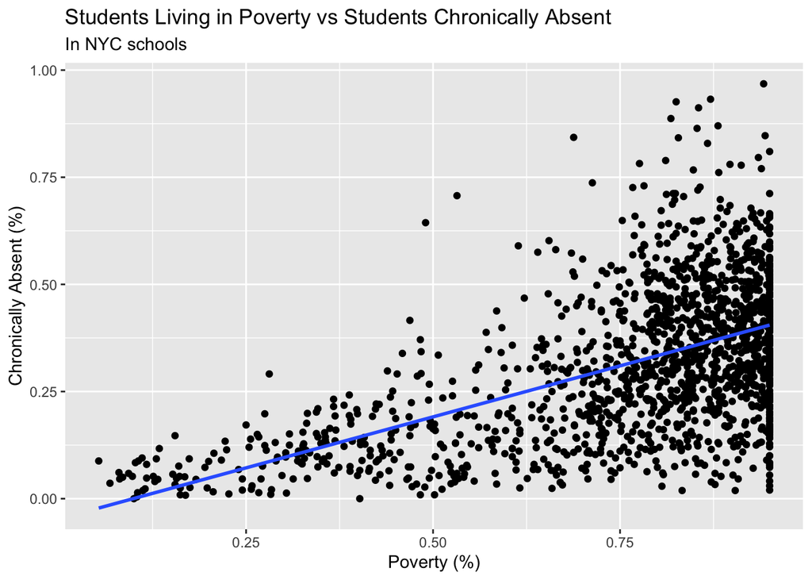

```r
#Figure 1

ggplot(data = joined_data, mapping = aes(x = Poverty, y = Chronically.Absent)) +
  geom_point() +
  geom_smooth(method = lm, se=FALSE, formula = y~x) +
  labs(title = "Students Living in Poverty vs Students Chronically Absent",
       subtitle = "In NYC schools",
       x ="Poverty (%)",
       y ="Chronically Absent (%)")
```

```r
absent_model <- lm(Chronically.Absent ~ Poverty, data = joined_data)
summary(absent_model)$coefficients
```

```
               Estimate Std. Error   t value      Pr(>|t|)
(Intercept) -0.04712545 0.01524435 -3.091338  2.028650e-03
Poverty      0.47596855 0.01920697 24.781030 3.331654e-114
```

These coefficients represent the unique effect of one explanatory variable on the outcome, after taking into account the effect of the other explanatory variables

**Intercept:** The predicted reported percentage of 0 chronically absent student population for a school with 0 percent reported poverty rate is -0.0471.

**Poverty:** For each additional 1 unit percent of students under the poverty line, the predicted reported percentage of chronically absent student population for a school increases by 0.476 on average.

```r
# Adding more coefficients

absent_model2 <- lm(Chronically.Absent ~ Poverty +
                                        English.Language.Learners +
                                        Students.with.Disabilities,
                                        data = joined_data)
summary(absent_model2)$coefficients
```

```
                              Estimate Std. Error   t value     Pr(>|t|)
(Intercept)                -0.08050046 0.01477039 -5.450126 5.862673e-08
Poverty                     0.45367609 0.02039543 22.244006 3.774391e-95
English.Language.Learners  -0.10069501 0.02744412 -3.669092 2.518001e-04
Students.with.Disabilities  0.27022199 0.02327341 11.610762 6.346969e-30
```

**Intercept:** The predicted reported percentage of 0 chronically absent student population for a school with 0 percent reported poverty rate, 0 percent reported population of student English language learners, and 0 percent reported population of students with disabilities is -0.081.

**Poverty:** For each additional 1 unit percent of students under the poverty line, the predicted reported percentage of chronically absent student population for a school increases by 0.453 on average.

**English Language Learners:** For each 1 percent increase in the student population who are english language learners, the predicted reported percentage of chronically absent student population for a school decreases by -0.101 on average, regardless of simultaneous changes in the percentage of students with disabilities

**Students with Disabilities** For each 1 percent increase in the student population who have disabilities, the predicted reported percentage of chronically absent student population for a school increases by 0.270 on average, regardless of simultaneous changes in the percentage of enlgish language learners.

Figure 2: Scatterplot Matrix

Figure 2 is a visualization that maps out the variables in an additive manner. The matrix plots all of our variables against each other in individual plots, so the first column plots ‘chronically absent’ vs poverty, then ‘english language learner’ then ‘student with disabilities’. It also plots a histogram of each variable and the correlation between variables.

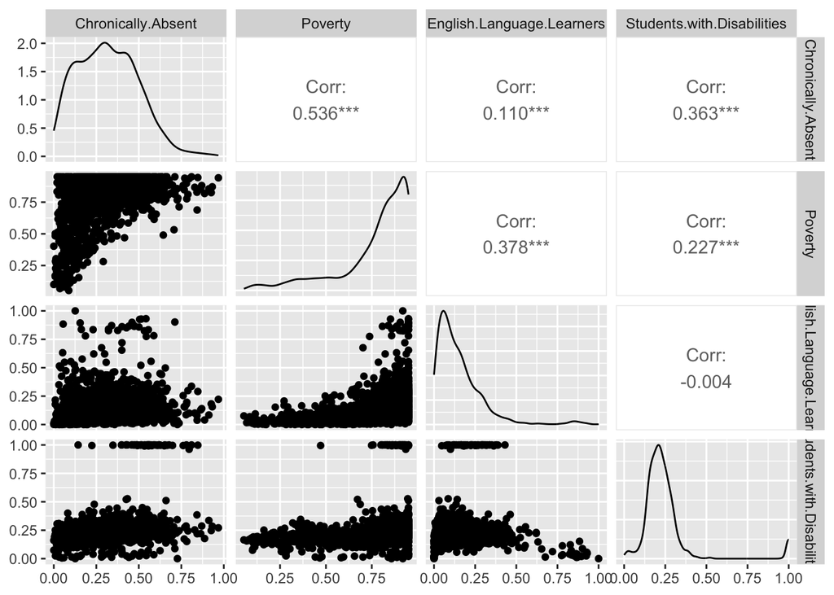

```r
#Figure 2: Scatterplot Matrix


data_minimal <- joined_data %>%
  select(Chronically.Absent,Poverty,
         English.Language.Learners,
         Students.with.Disabilities)

ggpairs(data_minimal)
```

# Data Analysis Appendix

The Fitted vs Residuals plot applies to both the linearity assumption as well as the equal variance/homogeneity assumption. When looking at this plot, we can see that the points do have a cone shape, therefore it does not pass the equal variance test. When looking for linearity we want to see that there is no relationship between the values and the residuals which we see in this plot the points are not randomly spread apart. Therefore, both assumptions are not met.

Our model’s failure of the normality and equal variance check are not completely negative outcomes. As stated before, we specifically care about the shape of the sampling distribution of the T statistic. The violation Since it would take an incredibly large violation of normality to get the sampling distribution and give it a different shape, a violation like ours would not dramatically change the shape of the T-distribution.

###Linearity Check

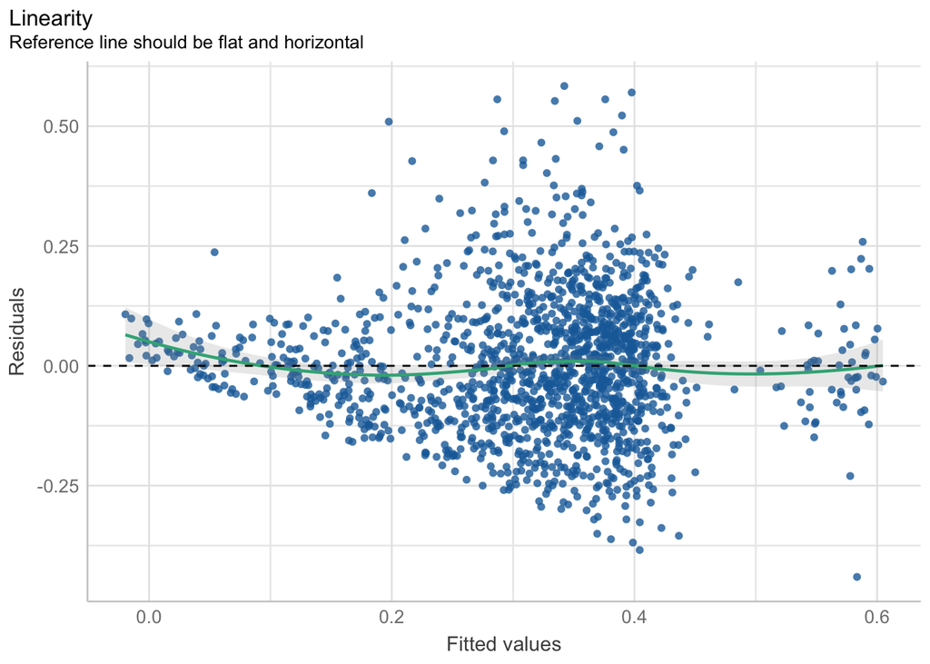

```r
plot(absent_model_3var_linearity_check, data=joined_data)
```

###Normality Check

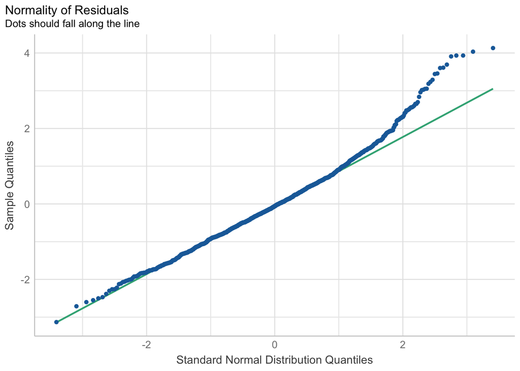

```r
plot(absent_model_3var_normality_check, data=joined_data)
```

###Homogeneity Check

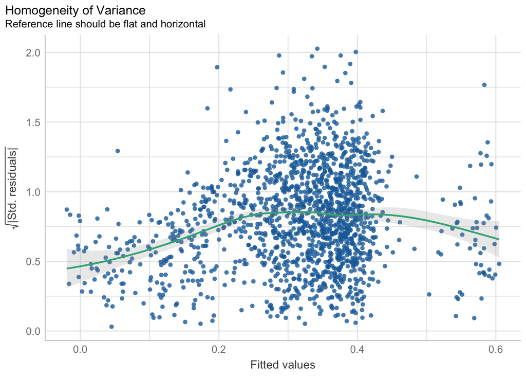

```r
plot(absent_model_3var_homoegeneity_check, data=joined_data)
```

# Citations

Center for Research in Education and Policy Research (2018). *Chronic Absenteeism and Its Impact on Achievement. CRESP Policy Brief Series.* Retrieved 2022, from https://www.cresp.udel.edu/wp-content/uploads/2018/07/P18-002.5_final.pdf

Chetty, R., Hendren, N., Jones, M., & Porter, S. (2020). *Race and Economic Opportunity in the United States: An intergenerational perspective.* Race and Economic Opportunity in the United States: An Intergenerational Perspective. Retrieved December 15, 2022, from https://scholar.harvard.edu/hendren/publications/race-and-economic-opportunity-united-states-intergenerational-perspective

Nauer, K., Mader, N., Robinson, G., Jacobs, T., Cory, B., Moss, J., & Bloodworth, A. (2014). *A Better Picture of Poverty What Chronic Absenteeism and Risk Load Reveal About NYC’s Lowest-Income Elementary Schools.* A Better Picture of Poverty | Attendance Works. Retrieved 2022, from http://static1.squarespace.com/static/53ee4f0be4b015b9c3690d84/t/547ccfefe4b03f842b275001/1417465839022/Better+Picture+of+Poverty_PA_FINAL.pdf

Zimmerman, A. (2022, September). *41% Of NYC students were chronically absent last school year.* Chalkbeat New York. https://ny.chalkbeat.org/2022/9/16/23357144/chronic-absenteeism-pandemic-nyc-school#:~:text=About%2041%25%20of%20New%20York,to%20city%20data%20released%20Friday.